# Practical Machine Learning Final Project

## Background

Using devices such as Jawbone Up, Nike FuelBand, and Fitbit it is now possible to collect a large amount of data about personal activity relatively inexpensively. These type of devices are part of the quantified self movement - a group of enthusiasts who take measurements about themselves regularly to improve their health, to find patterns in their behavior, or because they are tech geeks. One thing that people regularly do is quantify how much of a particular activity they do, but they rarely quantify how well they do it. In this project, we will use data from accelerometers on the belt, forearm, arm, and dumbell of 6 participants. They were asked to perform barbell lifts correctly and incorrectly in 5 different ways. More information is available from the website here: http://groupware.les.inf.puc-rio.br/har (see the section on the Weight Lifting Exercise Dataset).

## Abstract

The goal of the project is to predict the manner in which they did the exercise. This is the “classe” variable in the training set. I will split the initial training set into 80% as a training dataset and 20% as validation dataset. Then a classification tree model, random forest model and gradient boosting method will be introduced to do analyses and predictions. After comparing the confusion matrices and accuaracies of these three models, I will choose the random forest model as the best model to predict the test data.

## Load the Packages

```r
library(caret)
library(randomForest)
library(rpart)
library(gbm)
```

## Load the Initial Training Data and Test Data

```r
initial_train <- read.csv("C:/Users/puddi_000/Documents/Fall 2016 Ph.D/UWM/John Hopkins Coursera/pml-training.csv")
initial_test <- read.csv("C:/Users/puddi_000/Documents/Fall 2016 Ph.D/UWM/John Hopkins Coursera/pml-testing.csv")
```

## Data Cleaning

Since we can see that there’re a lot of missing values in both datasets, we remove the columns (variables) which contain

missing values before we build a model.

```r
training <- initial_train[, colSums(is.na(initial_train)) == 0]
testing <- initial_test[, colSums(is.na(initial_test)) == 0]
```

Also, we can see that the first seven variables which are not related to the “classe”, so we also remove these seven variables.

```r
training <- training[, -c(1:7)]
testing <- testing[, -c(1:7)]
```

Now, we can check how many observations and variables left after cleaning.

```r
dim(training)
```

```
## [1] 19622    86
```

```r
dim(testing)
```

```
## [1] 20 53
```

There’re 19622 observations and 86 variables left in the training data. There’re 20 observations and 53 variables left in the test data.

## Data Splitting

Next, we split the training data into 80% as training data and 20% as validation data.

```r
set.seed(123)
inTrain <- createDataPartition(training$classe, p = 0.8, list = FALSE)
traindata <- data.frame(training[inTrain, ])
validdata <- data.frame(training[-inTrain, ])
```

```r
dim(traindata)
```

```
## [1] 15699    86
```

```r
dim(validdata)
```

```
## [1] 3923   86
```

After splitting the training data into a new training dataset and validation dataset, we can see there’re 15699 observations and 86 variables in the new training dataset, and 3923 observations and 86 variables in the validation dataset.

## Data Exploration

1. Now, we are going to remove the variables which are near-zero-variance so that we can avoid constant and almost constant variables.

```r
nzv <- nearZeroVar(traindata)
traindata <- traindata[, -nzv]
validdata <- validdata[, -nzv]
dim(traindata)
```

```
## [1] 15699    53
```

```r
dim(validdata)
```

```
## [1] 3923   53
```

So now we have 53 variables left in both training data and validation data.

2. The correlation matrix can help us to see how many highly correlated variables.

```r
M <- abs(cor(traindata[, -53]))
diag(M) <- 0
which(M > 0.8, arr.ind = T)
```

```
##                  row col
## yaw_belt           3   1
## total_accel_belt   4   1
## accel_belt_y       9   1
## accel_belt_z      10   1
## accel_belt_x       8   2
## magnet_belt_x     11   2
## roll_belt          1   3
## roll_belt          1   4
## accel_belt_y       9   4
## accel_belt_z      10   4
## pitch_belt         2   8
## magnet_belt_x     11   8
## roll_belt          1   9
## total_accel_belt   4   9
## accel_belt_z      10   9
## roll_belt          1  10
## total_accel_belt   4  10
## accel_belt_y       9  10
## pitch_belt         2  11
## accel_belt_x       8  11
## magnet_belt_z     13  12
## magnet_belt_y     12  13
## gyros_arm_y       19  18
## gyros_arm_x       18  19
## magnet_arm_x      24  21
## accel_arm_x       21  24
## magnet_arm_z      26  25
## magnet_arm_y      25  26
## accel_dumbbell_x  34  28
## accel_dumbbell_z  36  29
## gyros_dumbbell_z  33  31
## gyros_forearm_z   46  31
## gyros_dumbbell_x  31  33
## gyros_forearm_z   46  33
## pitch_dumbbell    28  34
## yaw_dumbbell      29  36
## gyros_forearm_z   46  45
## gyros_dumbbell_x  31  46
## gyros_dumbbell_z  33  46
## gyros_forearm_y   45  46
```

The above result shows that there’re many variables are highly correlated with some other variables. In order to reduce the correlated variables, we are going to apply Principal component Analysis (PCA) to the data.

3. Thus, we are going to calculate the principal components of the training data and validation data.

```r
preProc <- preProcess(traindata[, -53], method = "pca", thresh = 0.8)
trainPC <- predict(preProc, traindata[, -53])
validPC <- predict(preProc, validdata[, -53])
```

Now, we combine the principal components in traindata and the “classe” variable together as a new training data. We are going to use this new training data to build models.

```r
newtrain <- data.frame(classe_train = traindata$classe,  trainPC)
```

Similarly, we combine the principal components in validdata and the “classe” variable together as a new validation data. We are going to use this new validation data to predeict.

```r
newvalid <- data.frame(classe_valid = validdata$classe, validPC)
```

## Model Selection

### Model 1: Classification Tree Model

```r
set.seed(321)
cartcontrol <- trainControl(method = "cv", number = 5)
cart_mod <- train(classe_train ~ ., data = newtrain, method = "rpart", trControl = cartcontrol)
print(cart_mod)
```

```
## CART
##
## 15699 samples
##    12 predictor
##     5 classes: 'A', 'B', 'C', 'D', 'E'
##
## No pre-processing
## Resampling: Cross-Validated (5 fold)
## Summary of sample sizes: 12560, 12559, 12559, 12560, 12558
## Resampling results across tuning parameters:
##
##   cp          Accuracy   Kappa
##   0.02501113  0.3788110  0.18681662
##   0.04405874  0.3432049  0.10985478
##   0.06559858  0.3211067  0.06492575
##
## Accuracy was used to select the optimal model using  the largest value.
## The final value used for the model was cp = 0.02501113.
```

1. Then we plot the classification tree to see how the model decides the “classe” variable.

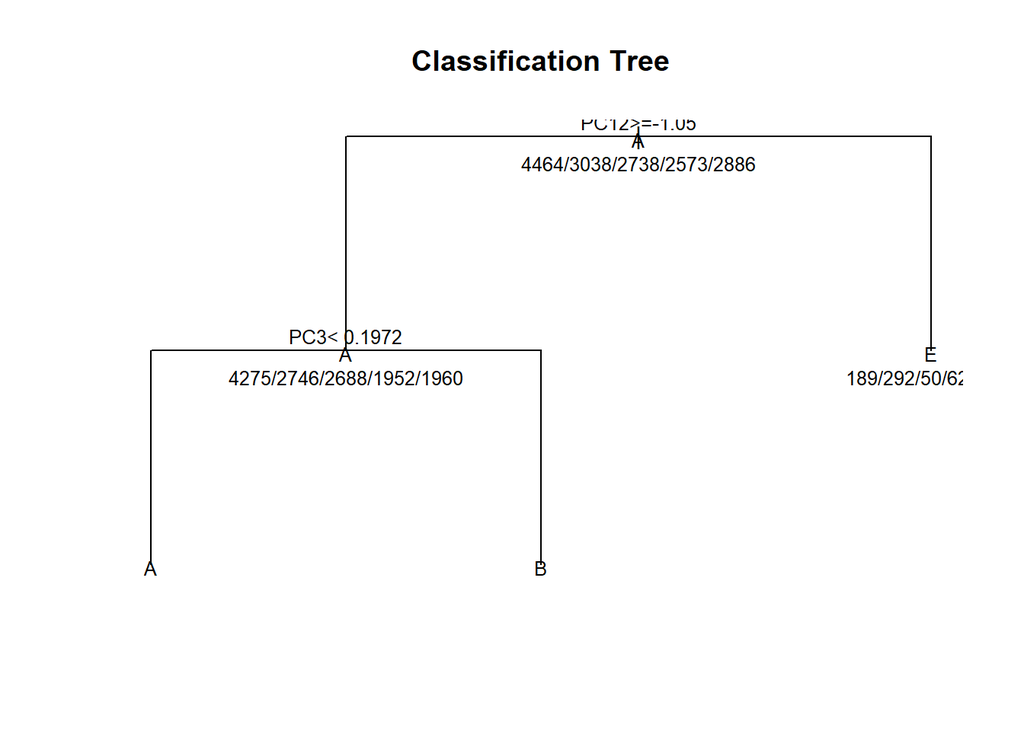

```r
plot(cart_mod$finalModel, uniform = TRUE, main = "Classification Tree")
text(cart_mod$finalModel, use.n = TRUE, all = TRUE, cex = .8)
```

2. Then we use the classfication model to predict the validation data.Here’re the results of the prediction.

```r
cart_pred <- predict(cart_mod, newdata = newvalid)
confusionMatrix(validdata$classe, cart_pred)
```

```
## Confusion Matrix and Statistics
##
##           Reference
## Prediction   A   B   C   D   E
##          A 810 252   0   0  54
##          B 310 360   0   0  89
##          C 443 231   0   0  10
##          D 217 285   0   0 141
##          E 203 292   0   0 226
##
## Overall Statistics
##
##                Accuracy : 0.3559
##                  95% CI : (0.3409, 0.3711)
##     No Information Rate : 0.5055
##     P-Value [Acc > NIR] : 1
##
##                   Kappa : 0.1544
##  Mcnemar's Test P-Value : NA
##
## Statistics by Class:
##
##                      Class: A Class: B Class: C Class: D Class: E
## Sensitivity            0.4085  0.25352       NA       NA  0.43462
## Specificity            0.8423  0.84059   0.8256   0.8361  0.85454
## Pos Pred Value         0.7258  0.47431       NA       NA  0.31345
## Neg Pred Value         0.5821  0.66498       NA       NA  0.90818
## Prevalence             0.5055  0.36197   0.0000   0.0000  0.13255
## Detection Rate         0.2065  0.09177   0.0000   0.0000  0.05761
## Detection Prevalence   0.2845  0.19347   0.1744   0.1639  0.18379
## Balanced Accuracy      0.6254  0.54706       NA       NA  0.64458
```

From the confusion matrix, we can see there’re many wrong classifications in all “classe” levels. Also, we can see that the accuracy is only about 0.36, which is very low. Actually, this model only can classify “Classe A”, “Classe B” and “Classe E”. So we are going to see if there is a better model for the data.

### Model 2: Random Forest Model

```r
rf_mod <- randomForest(classe_train ~ ., data = newtrain)
print(rf_mod)
```

```
##
## Call:
##  randomForest(formula = classe_train ~ ., data = newtrain)
##                Type of random forest: classification
##                      Number of trees: 500
## No. of variables tried at each split: 3
##
##         OOB estimate of  error rate: 3.54%
## Confusion matrix:
##      A    B    C    D    E class.error
## A 4361   31   42   24    6  0.02307348
## B   61 2884   68   12   13  0.05069124
## C   26   35 2646   24    7  0.03360117
## D   15   11  105 2432   10  0.05479984
## E    5   20   16   25 2820  0.02286902
```

We use this random forest model to predict the validation data. Here’re the results of the prediction.

```r
rf_pred <- predict(rf_mod, newdata = newvalid)
confusionMatrix(validdata$classe, rf_pred)
```

```
## Confusion Matrix and Statistics
##
##           Reference
## Prediction    A    B    C    D    E
##          A 1084    6   10   11    5
##          B   16  732    9    2    0
##          C    5   12  658    7    2
##          D    8    4   24  604    3
##          E    0    4    3    2  712
##
## Overall Statistics
##
##                Accuracy : 0.9661
##                  95% CI : (0.9599, 0.9715)
##     No Information Rate : 0.2837
##     P-Value [Acc > NIR] : < 2.2e-16
##
##                   Kappa : 0.9571
##  Mcnemar's Test P-Value : 0.003119
##
## Statistics by Class:
##
##                      Class: A Class: B Class: C Class: D Class: E
## Sensitivity            0.9739   0.9657   0.9347   0.9649   0.9861
## Specificity            0.9886   0.9915   0.9919   0.9882   0.9972
## Pos Pred Value         0.9713   0.9644   0.9620   0.9393   0.9875
## Neg Pred Value         0.9897   0.9918   0.9858   0.9933   0.9969
## Prevalence             0.2837   0.1932   0.1795   0.1596   0.1840
## Detection Rate         0.2763   0.1866   0.1677   0.1540   0.1815
## Detection Prevalence   0.2845   0.1935   0.1744   0.1639   0.1838
## Balanced Accuracy      0.9813   0.9786   0.9633   0.9765   0.9917
```

From the confusion matrix, we can see there’re much more correct classifications than wrong classifications in all “classe” levels. Also, we can see that the accuracy is about 0.97, which is pretty good and much higher than the accuracy of the classification model. So the random forest model probably is the optimal method for the data. We can also check one more model to see if there is a better model than this one.

### Model 3: Gradient Boosted Model (GBM)

```r
set.seed(12345)
gbmcontrol <- trainControl(method = "cv", number = 5)
gbm_mod <- train(classe_train ~ ., data = newtrain, method = "gbm", trControl = gbmcontrol, verbose = FALSE)
```

```r
print(gbm_mod)
```

```
## Stochastic Gradient Boosting
##
## 15699 samples
##    12 predictor
##     5 classes: 'A', 'B', 'C', 'D', 'E'
##
## No pre-processing
## Resampling: Cross-Validated (5 fold)
## Summary of sample sizes: 12560, 12559, 12559, 12558, 12560
## Resampling results across tuning parameters:
##
##   interaction.depth  n.trees  Accuracy   Kappa
##   1                   50      0.5118155  0.3720511
##   1                  100      0.5550020  0.4319672
##   1                  150      0.5800996  0.4654139
##   2                   50      0.5977440  0.4888263
##   2                  100      0.6602958  0.5691204
##   2                  150      0.6980693  0.6171608
##   3                   50      0.6490852  0.5549660
##   3                  100      0.7175614  0.6421654
##   3                  150      0.7503649  0.6838179
##
## Tuning parameter 'shrinkage' was held constant at a value of 0.1
##
## Tuning parameter 'n.minobsinnode' was held constant at a value of 10
## Accuracy was used to select the optimal model using  the largest value.
## The final values used for the model were n.trees = 150,
##  interaction.depth = 3, shrinkage = 0.1 and n.minobsinnode = 10.
```

We use this GBM model to predict the validation data. Here’re the results of the prediction.

```r
gbm_pred <- predict(gbm_mod, newdata = newvalid)
confusionMatrix(validdata$classe, gbm_pred)
```

```
## Confusion Matrix and Statistics
##
##           Reference
## Prediction   A   B   C   D   E
##          A 914  37  71  79  15
##          B  85 511  84  29  50
##          C  98  45 511  11  19
##          D  47  26  74 478  18
##          E  38  67  64  30 522
##
## Overall Statistics
##
##                Accuracy : 0.7484
##                  95% CI : (0.7345, 0.7619)
##     No Information Rate : 0.3013
##     P-Value [Acc > NIR] : < 2.2e-16
##
##                   Kappa : 0.6812
##  Mcnemar's Test P-Value : < 2.2e-16
##
## Statistics by Class:
##
##                      Class: A Class: B Class: C Class: D Class: E
## Sensitivity            0.7733   0.7449   0.6356   0.7624   0.8365
## Specificity            0.9263   0.9234   0.9445   0.9499   0.9397
## Pos Pred Value         0.8190   0.6733   0.7471   0.7434   0.7240
## Neg Pred Value         0.9045   0.9447   0.9095   0.9546   0.9681
## Prevalence             0.3013   0.1749   0.2049   0.1598   0.1591
## Detection Rate         0.2330   0.1303   0.1303   0.1218   0.1331
## Detection Prevalence   0.2845   0.1935   0.1744   0.1639   0.1838
## Balanced Accuracy      0.8498   0.8341   0.7901   0.8561   0.8881
```

Thus, we are going to choose the random forest model as the best model for the data.

## Conclusion

Now we are going to apply the random forest model to the test data. But before we do that, we need to calculate the principal components of the test data first. We do this because the random forest model is based on the new training data which was tranformed by PCA.

```r
testPC <- predict(preProc, testing[, -53])
```

Then we can use the model to predict the “Classe” variable with the test data.

```r
test_pred <- predict(rf_mod, newdata = testPC)
test_pred
```

```
##  1  2  3  4  5  6  7  8  9 10 11 12 13 14 15 16 17 18 19 20
##  B  A  A  A  A  E  D  B  A  A  A  C  B  A  E  E  A  B  B  B
## Levels: A B C D E
```

The above result is the prediction of the 20 test cases.